Universidad El Bosque

Muestreo Estadístico

Capítulo 6 · Sesión 1 de 2 · Semana 12

# Probabilidades desiguales

Sesión 1 — por qué PPT, Hansen–Hurwitz, cómo se sortea, Horvitz–Thompson sin reemplazo y el diseño πPT

Por qué PPTHansen–HurwitzAcumulativo y LahiriHorvitz–ThompsonπPT y Raj

**Javier Mauricio Sierra**

Universidad El Bosque

Muestreo Estadístico

Capítulo 6 · Probabilidades desiguales

¿Por qué probabilidades desiguales?

El estimador de Hansen–Hurwitz

Cómo se sortea: acumulativo y Lahiri

Sin reemplazo: Horvitz–Thompson otra vez

El diseño πPT y cuándo gana

Cierre de la sesión 1

Hoja de ruta

## Lo que vamos a construir hoy

Objetivo de la sesión

Estimar con probabilidades desiguales, con y sin reemplazo, y anticipar antes de muestrear si el diseño proporcional al tamaño le gana al MAS.

Por qué PPTHansen–HurwitzAcumulativo y LahiriHorvitz–ThompsonπPT y Raj

2 / 38

Universidad El Bosque

Muestreo Estadístico

Capítulo 6 · Probabilidades desiguales

¿Por qué probabilidades desiguales?

El estimador de Hansen–Hurwitz

Cómo se sortea: acumulativo y Lahiri

Sin reemplazo: Horvitz–Thompson otra vez

El diseño πPT y cuándo gana

Cierre de la sesión 1

01

## ¿Por qué probabilidades desiguales?

Cuatro tiendas y una sola visita: con el sorteo de siempre, la estimación del total puede salir 44 o 980; con el proporcional al área, entre 128 y 392.

Leer en el material: ¿Por qué probabilidades desiguales?

3 / 38

¿Por qué probabilidades desiguales?

## Cada cifra trae su fuente y cada frase dice qué es

### Dato

Sale de los datos o del código del capítulo, también de un sorteo con su semilla: se puede recalcular.

### `Lectura`

Lo que el material, Lohr o Gutiérrez concluyen de esa cifra: una interpretación.

### Opinión del material

Un juicio o una regla práctica del autor. Va en una caja ámbar con ese título: es defendible, pero no se mide.

Al pie, la **fuente**. Las cifras elegidas a mano y las poblaciones inventadas van en una caja «Ejemplo ilustrativo». Definiciones y fórmulas: teoría, sin marca.

Lohr, S. L. (2022). *Sampling: Design and Analysis* (3.ª ed.). CRC Press. · Gutiérrez, H. A. *Estrategias de muestreo*, cap. 4 (en línea). · Material: capítulo 6, *Probabilidades desiguales*.

Capítulo 6 · Probabilidades desigualesMuestreo Estadístico · UnBosque4 / 38

¿Por qué probabilidades desiguales?

## Cuando las unidades son muy distintas, sortearlas por igual desperdicia lo que ya se sabe

| Tienda | Área \(x_i\) (m²) | Ventas \(t_i\) (miles de USD) |
| --- | --- | --- |
| A | 100 | 11 |
| B | 200 | 20 |
| C | 300 | 24 |
| D | 1000 | 245 |
| **Total** | 1600 | 300 |

- Dato D tiene diez veces el área de A y hace el 82 % de las ventas
- Se quiere el total de ventas del mes. El área es la **medida de tamaño**: se conoce para todo el marco antes de muestrear; las ventas, solo de la tienda que salga
- **PPT:** cada unidad sale con probabilidad proporcional a su tamaño, \(\psi_i = x_i/t_x\), con \(t_x = \sum x_i = 1600\)

Fuente: cap. 6, módulo 1 (y su nota «La medida de tamaño»); Lohr 3.ª ed., §6.1 y Tabla 6.1.

Capítulo 6 · Probabilidades desigualesMuestreo Estadístico · UnBosque5 / 38

¿Por qué probabilidades desiguales?

## Se divide lo observado entre su probabilidad de salir

Probabilidad de selección \(\psi_i\) y su estimador

En un sorteo de **una extracción**, \(\psi_i\) es la probabilidad de que salga la unidad \(i\); las \(\psi_i\) del marco suman 1. Si sale \(i\), el total se estima con \(\hat{t}_\psi = t_i/\psi_i\).

- A ocupa 100 de los 1600 m²: \(\psi_A = 1/16\)
- Si sale A, sus ventas valen por las de 16 «tiendas como A»: \(16 \times 11 = 176\)
- Cada dato lleva el peso \(1/\psi_i\), el de siempre

Fuente: cap. 6, módulo 1 (definición y tabla de las cuatro tiendas).

Capítulo 6 · Probabilidades desigualesMuestreo Estadístico · UnBosque6 / 38

¿Por qué probabilidades desiguales?

## Los dos sorteos son insesgados; el proporcional tiene 10,8 veces menos varianza

[figure not shown]

Lo que estima cada tienda si sale: primero con ψ proporcional al área, después con ψ = 1/4

- Dato \(E(\hat{t}) = 300\) con los dos sorteos
- Dato \(V = 14\,248\) con \(\psi \propto\) área; \(154\,488\) con \(\psi = 1/4\)
- `Lectura` elegir las \(\psi\) no toca el sesgo: decide la varianza

Fuente: cap. 6, módulo 1, bloque «Las cuatro tiendas: dos sorteos enumerados exactos».

Capítulo 6 · Probabilidades desigualesMuestreo Estadístico · UnBosque7 / 38

Pregunta para la clase

## ¿De dónde sale exactamente la ganancia de 10,8?

Con las cuatro tiendas, los dos sorteos son insesgados, pero el proporcional tiene 10,8 veces menos varianza. ¿Por qué?

1. Con \(\psi \propto\) tamaño, los cocientes \(t_i/\psi_i\) quedan cerca de 300
2. El proporcional saca la tienda D más a menudo, y D es la que más informa
3. Las probabilidades desiguales eliminan el sesgo de selección del sorteo uniforme

Respuesta

La 1: 176, 160, 128 y 392, frente a 44, 80, 96 y 980. La 2 confunde observar más con estimar mejor. La 3: no había sesgo que eliminar.

Fuente: cap. 6, módulo 11, pregunta 1 de la autoevaluación.

Capítulo 6 · Probabilidades desigualesMuestreo Estadístico · UnBosque8 / 38

Idea clave · la idea central del capítulo

## La varianza es pequeña cuando \(t_i/\psi_i\) cambia poco de una unidad a otra

Eso ocurre cuando la probabilidad de cada unidad acompaña a su valor. Sin reemplazo, desde el módulo 4, la misma idea se escribe con \(y_k/\pi_k\).

Capítulo 6 · Probabilidades desigualesMuestreo Estadístico · UnBosque9 / 38

¿Por qué probabilidades desiguales?

## Sin el peso de cada dato, la estimación pasa del doble

Dato Si se sortea con \(\psi \propto\) área pero se expande como si todas tuvieran 1/4, con \(4\,t_i\), la estimación vale en promedio

$$\sum_i \psi_i \cdot 4\,t_i = 643{,}25 \qquad \text{en vez de } 300$$

- `Lectura` las unidades grandes salen más a menudo; sin su peso \(1/\psi_i\), se cuentan de más

Fuente: cap. 6, módulo 1 (advertencia «El precio: cada dato lleva su peso» y última salida del bloque del módulo).

Capítulo 6 · Probabilidades desigualesMuestreo Estadístico · UnBosque10 / 38

Universidad El Bosque

Muestreo Estadístico

Capítulo 6 · Probabilidades desiguales

¿Por qué probabilidades desiguales?

El estimador de Hansen–Hurwitz

Cómo se sortea: acumulativo y Lahiri

Sin reemplazo: Horvitz–Thompson otra vez

El diseño πPT y cuándo gana

Cierre de la sesión 1

02

## El estimador de Hansen–Hurwitz

Repetir el sorteo n veces, con reemplazo, y promediar: la varianza se divide entre n y se estima con la cuenta de siempre.

Leer en el material: El estimador de Hansen–Hurwitz

11 / 38

El estimador de Hansen–Hurwitz

## Hansen–Hurwitz (HH) promedia \(n\) estimaciones independientes, una por extracción

$$\hat{t}_{HH} = \frac{1}{n}\sum_{j=1}^{n} z_j, \qquad z_j = \frac{t_i}{\psi_i} \ \text{ si en la extracción } j \text{ salió } i$$

$$V(\hat{t}_{HH}) = \frac{1}{n}\sum_{i=1}^{N} \psi_i\left(\frac{t_i}{\psi_i} - t\right)^2 \qquad\qquad \widehat{V}(\hat{t}_{HH}) = \frac{s_z^2}{n}$$

- Cada \(z_j\) es la estimación del módulo 1: su promedio es insesgado
- \(V\) recorre todo el marco: sirve para el cálculo exacto
- \(\widehat{V}\) es \(s^2/n\) con los \(z_j\): las extracciones son independientes

Fuente: cap. 6, módulo 2 (fórmula); Lohr 3.ª ed., §6.2; Gutiérrez, Resultado 4.2.4.

Capítulo 6 · Probabilidades desigualesMuestreo Estadístico · UnBosque12 / 38

El estimador de Hansen–Hurwitz

## Con dos extracciones, la varianza baja a la mitad: 7124

Hansen-Hurwitz con dos extracciones, enumerado

```
pares <- expand.grid(prima = 1:4, segunda = 1:4)
pares$prob <- tiendas$psi[pares$prima] * tiendas$psi[pares$segunda]
pares$hh <- (est_ppt[pares$prima] + est_ppt[pares$segunda]) / 2
c(E_HH = sum(pares$prob * pares$hh),
  V_enumerada = sum(pares$prob * (pares$hh - t_total)^2),
  V_formula = sum(tiendas$psi * (est_ppt - t_total)^2) / 2)
#>        E_HH V_enumerada   V_formula
#>         300        7124        7124
```

- Dato los 16 pares ordenados y la fórmula dan 7124, la mitad de 14 248
- `Lectura` las dos extracciones son independientes: por eso la varianza se divide entre \(n\)

Fuente: cap. 6, módulo 2, bloque «Hansen-Hurwitz enumerado y sorteado» (pestaña R, primera parte). Usa `tiendas`, `est_ppt` y `t_total`, del bloque del módulo 1.

Capítulo 6 · Probabilidades desigualesMuestreo Estadístico · UnBosque13 / 38

El estimador de Hansen–Hurwitz

## Con una muestra, el error estándar estimado es 132; el verdadero, 84

Una muestra de dos extracciones

```
set.seed(2026)
s <- sample(1:4, 2, replace = TRUE, prob = tiendas$psi)
paste(tiendas$tienda[s], collapse = "")
#> [1] "CD"
z <- tiendas$ventas[s] / tiendas$psi[s]
c(t_hat = mean(z), ee_estimado = sqrt(var(z) / 2))
#>       t_hat ee_estimado
#>         260         132
```

- Dato la muestra CD estima 260, con un error estándar (ee) estimado de 132
- Dato el verdadero es \(\sqrt{7124} \approx 84\)
- `Lectura` con dos datos, \(s_z^2\) es poco fiable; el estimador puntual ya usa bien los tamaños

Fuente: cap. 6, módulo 2, bloque «Hansen-Hurwitz enumerado y sorteado» (pestaña R, segunda parte). Usa `tiendas`, del bloque del módulo 1.

Capítulo 6 · Probabilidades desigualesMuestreo Estadístico · UnBosque14 / 38

Pregunta para la clase

## ¿Cuántas extracciones bastan para una varianza menor que 1000?

Con las tiendas, \(V(n = 1) = 14\,248\), y la varianza del HH es \(V(n = 1)/n\). ¿Cuál es el menor \(n\) entero?

Respuesta

**15.** Hay que pedir \(14\,248/n < 1000\), es decir, \(n > 14{,}248\): con 14 extracciones la varianza queda en 1017,7, y con 15, en 949,9.

Fuente: cap. 6, módulo 11, pregunta 2 de la autoevaluación.

Capítulo 6 · Probabilidades desigualesMuestreo Estadístico · UnBosque15 / 38

Universidad El Bosque

Muestreo Estadístico

Capítulo 6 · Probabilidades desiguales

¿Por qué probabilidades desiguales?

El estimador de Hansen–Hurwitz

Cómo se sortea: acumulativo y Lahiri

Sin reemplazo: Horvitz–Thompson otra vez

El diseño πPT y cuándo gana

Cierre de la sesión 1

03

## Cómo se sortea: acumulativo y Lahiri

Para sortear con probabilidades desiguales hace falta un algoritmo: una receta que convierta uniformes en unidades con las \(\psi\) pedidas.

Leer en el material: Cómo se sortea: acumulativo y Lahiri

16 / 38

Cómo se sortea: acumulativo y Lahiri

## El acumulativo: cada unidad ocupa un tramo tan largo como su tamaño

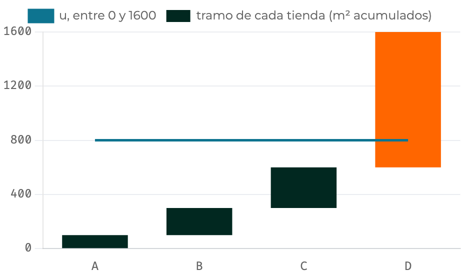

El simulador del módulo 3 en su estado inicial: los tramos acumulados y la recta u = 800, que cae en D

1. Acumular los tamaños: A 1–100, B 101–300, C 301–600, D 601–1600
2. Sortear \(u\) entre 0 y \(t_x = 1600\)
3. Sale la unidad en cuyo tramo cae \(u\)

Dato D ocupa 1000 de 1600 puntos: sale el 62,5 % de las veces.

**Costo:** recorrer el marco entero antes del primer sorteo.

Fuente: cap. 6, módulo 3 (método acumulativo, Hansen, Hurwitz y Madow, 1953); Lohr 3.ª ed., §6.2.1; Gutiérrez, §4.2.1.

Capítulo 6 · Probabilidades desigualesMuestreo Estadístico · UnBosque17 / 38

Cómo se sortea: acumulativo y Lahiri

## Lahiri: se acepta la candidata con probabilidad \(x_i/x_{\max}\)

1Candidatauna unidad al azar, todas con probabilidad \(1/N\)

→

2Uniforme\(u\) entre 0 y \(x_{\max} = 1000\), al menos el mayor tamaño

→

3Decidirsi \(u \le x_i\), sale; si no, se vuelve al paso 1

- Dato en un intento: A 0,025, B 0,05, C 0,075 y D 0,25; suman 0,4
- Entre las aceptadas, D sale \(0{,}25/0{,}4 = 0{,}625\) de las veces: su \(\psi_D\)
- **Costo:** \(1/0{,}4 = 2{,}5\) intentos por selección; Dato el bloque mide 2,51

Fuente: cap. 6, módulo 3 (método de Lahiri, 1951, y su bloque); Lohr 3.ª ed., §6.2.1; Gutiérrez, §4.2.1.

Capítulo 6 · Probabilidades desigualesMuestreo Estadístico · UnBosque18 / 38

Pregunta para la clase

## Un marco de 40 millones que no cabe en memoria: ¿qué método?

No se puede recorrer antes de sortear, pero se puede leer cualquier unidad por su número, y se conocen \(N\) y \(x_{\max}\).

1. El acumulativo, porque es exacto y Lahiri solo aproxima las \(\psi\)
2. Lahiri, porque al rechazar las unidades pequeñas tiene menos varianza
3. Lahiri: sortea entre 1 y \(N\) y acepta o rechaza contra \(x_{\max}\)

Respuesta

La 3: el acumulativo exige sumar todo el marco antes del primer sorteo. Los dos son exactos y tienen la misma varianza; la diferencia es de memoria y de pasadas.

Fuente: cap. 6, módulo 11, pregunta 3 de la autoevaluación.

Capítulo 6 · Probabilidades desigualesMuestreo Estadístico · UnBosque19 / 38

Universidad El Bosque

Muestreo Estadístico

Capítulo 6 · Probabilidades desiguales

¿Por qué probabilidades desiguales?

El estimador de Hansen–Hurwitz

Cómo se sortea: acumulativo y Lahiri

Sin reemplazo: Horvitz–Thompson otra vez

El diseño πPT y cuándo gana

Cierre de la sesión 1

04

## Sin reemplazo: Horvitz–Thompson otra vez

Quitar el reemplazo no pide teoría nueva: el HT del capítulo 2 vale igual. Pero quitarlo no basta para ganar.

Leer en el material: Sin reemplazo: Horvitz–Thompson otra vez

20 / 38

Sin reemplazo: Horvitz–Thompson otra vez

## El HT del capítulo 2 sirve con cualquier diseño con \(\pi_k > 0\)

$$\hat{t}_\pi = \sum_{k \in s} \frac{y_k}{\pi_k}, \qquad E(\hat{t}_\pi) = \sum_{k \in U} \frac{y_k}{\pi_k}\,E(I_k) = \sum_{k \in U} \frac{y_k}{\pi_k}\,\pi_k = t$$

- \(I_k\) vale 1 si \(k\) sale y 0 si no: \(E(I_k) = \pi_k\)
- \(\pi_k\) es la suma de \(p(s)\) sobre las muestras que contienen a \(k\); con tamaño fijo, suman \(n\)
- El MAS es el caso \(\pi_k = n/N\); nada obliga a que sean iguales
- Desde aquí: valor \(y_k\) e índice \(k\), como en el capítulo 2

Fuente: cap. 6, módulo 4 (fórmula); Lohr 3.ª ed., §6.4; Gutiérrez, §4.3.

Capítulo 6 · Probabilidades desigualesMuestreo Estadístico · UnBosque21 / 38

Sin reemplazo: Horvitz–Thompson otra vez

## Con \(p(s) \propto x_k + x_l\), el HT de las tiendas tiene más varianza que el HH

Seis parejas sin reemplazo

```
muestras <- t(combn(4, 2))
p_s <- tiendas$m2[muestras[, 1]] + tiendas$m2[muestras[, 2]]
p_s <- p_s / sum(p_s)
pi_k <- sapply(1:4, function(k) sum(p_s[apply(muestras == k, 1, any)]))
round(pi_k, 4)
#> [1] 0.3750 0.4167 0.4583 0.7500
ht_s <- apply(muestras, 1, function(m) sum(tiendas$ventas[m] / pi_k[m]))
c(E_HT = sum(p_s * ht_s), V_HT = sum(p_s * (ht_s - t_total)^2))
#>     E_HT     V_HT
#>   300.00 15025.67
round(tiendas$ventas / pi_k, 1)
#> [1]  29.3  48.0  52.4 326.7
```

- Dato \(\pi_k\) de 0,375 a 0,75; el HT es insesgado y \(V = 15\,026\)
- Dato más del doble que el HH con reemplazo (7124), con el mismo \(n\)
- `Lectura` el cociente de D, 326,7, queda lejísimos de los otros tres

Fuente: cap. 6, módulo 4, bloque «Espacio de muestras sin reemplazo» (pestaña R). Usa `tiendas` y `t_total`, del bloque del módulo 1.

Capítulo 6 · Probabilidades desigualesMuestreo Estadístico · UnBosque22 / 38

Pregunta para la clase

## ¿Qué probabilidad tiene D de estar en la muestra?

Se sortean dos tiendas con reemplazo, con \(\psi_D = 0{,}625\).

1. 1,25, que es \(n\,\psi_D = 2 \times 0{,}625\)
2. 0,625, que es \(\psi_D\)
3. 0,75, la \(\pi_D\) del diseño sin reemplazo con \(p(s) \propto x_k + x_l\)
4. 0,8594, que es \(1 - (1 - 0{,}625)^2\)

Respuesta

La 4: uno menos la probabilidad de que D no salga en ninguna. La 1 es el número medio de veces que sale D; la 2, la de una extracción; la 3, la de otro diseño.

Fuente: cap. 6, módulo 11, pregunta 4 de la autoevaluación.

Capítulo 6 · Probabilidades desigualesMuestreo Estadístico · UnBosque23 / 38

Sin reemplazo: Horvitz–Thompson otra vez

## Dos probabilidades que no hay que confundir: \(\psi\) y \(\pi\)

|  | Con reemplazo | Sin reemplazo |
| --- | --- | --- |
| Probabilidad | \(\psi_i\): salir en **una extracción** | \(\pi_k\): estar **en la muestra** |
| Suman | 1 | \(n\), con tamaño fijo |
| Peso de cada dato | \(1/(n\,\psi_i)\) | \(1/\pi_k\) |

- Dato \(\pi \approx n\,\psi\) solo si \(\psi\) es pequeña. A: \(n\psi = 0{,}125\) y \(\pi = 0{,}121\); D: \(n\psi = 1{,}25\) y \(\pi = 0{,}859\)
- Esa aproximación permite analizar un diseño sin reemplazo como si fuera con reemplazo (sesión 2)

Fuente: cap. 6, módulo 4 (definición, tabla y bloque «psi frente a pi con las cuatro tiendas»).

Capítulo 6 · Probabilidades desigualesMuestreo Estadístico · UnBosque24 / 38

Sin reemplazo: Horvitz–Thompson otra vez

## En estas tiendas, la varianza baja cuando el diseño deja fuera a D con menos probabilidad

| Diseño, \(n = 2\) | Prob. sin D | \(V\) de las muestras sin D | \(V\) |
| --- | --- | --- | --- |
| \(p(s) \propto x_k + x_l\) | 0,25 | 75 % | 15 026 |
| Hansen–Hurwitz, con reemplazo | 0,14 | 47 % | 7124 |
| Lohr, extracción a extracción | 0,10 | 89 % | 4384 |
| πPT (lo construye el módulo 5) | 0 | — | 53 |

`Lectura` Sin reemplazo no es automáticamente mejor: con las mismas tiendas, un diseño sin reemplazo queda por encima del HH y otro por debajo.

Fuente: cap. 6, módulo 4, bloque «El diseño de Lohr, extracción a extracción» y su tabla; Lohr 3.ª ed., ejs. 6.8 y 6.9.

Capítulo 6 · Probabilidades desigualesMuestreo Estadístico · UnBosque25 / 38

Universidad El Bosque

Muestreo Estadístico

Capítulo 6 · Probabilidades desiguales

¿Por qué probabilidades desiguales?

El estimador de Hansen–Hurwitz

Cómo se sortea: acumulativo y Lahiri

Sin reemplazo: Horvitz–Thompson otra vez

El diseño πPT y cuándo gana

Cierre de la sesión 1

05

## El diseño πPT y cuándo gana

Se piden las \(\pi\) directamente, proporcionales al tamaño. Si \(y\) acompaña a \(x\), la varianza se anula; si no, el diseño puede perder contra el MAS.

Leer en el material: El diseño πPT y cuándo gana

26 / 38

El diseño πPT y cuándo gana

## πPT: \(\pi_k = n\,x_k/t_x\), y la unidad que pase de 1 entra siempre

$$\pi_k = n\,\frac{x_k}{t_x}$$

Inclusión forzosa

Si \(n\,x_k/t_x > 1\), la unidad entra en todas las muestras: \(\pi_k = 1\), y no aporta varianza. Los cupos que quedan se reparten entre las demás en proporción a su tamaño; si otra pasa de 1, se repite el paso.

- Dato tiendas, \(n = 2\): D forzosa; \(\pi_A = 1/6\), \(\pi_B = 1/3\), \(\pi_C = 1/2\)
- Dato tres muestras posibles, {A, D}, {B, D} y {C, D}, con HT de 311, 305 y 293: \(V = 53\)

Fuente: cap. 6, módulo 5, bloque «El piPT con las cuatro tiendas»; Gutiérrez, §4.3 (ej. 4.3.1); Lohr 3.ª ed., §6.4.

Capítulo 6 · Probabilidades desigualesMuestreo Estadístico · UnBosque27 / 38

El diseño πPT y cuándo gana

## statepps: 51 estados, \(n = 10\), y California entra siempre

Las pi del diseño y la inclusión forzosa

```
statepps <- read.csv("CSV data sets for SDA 3e/statepps.csv")
c(estados = nrow(statepps), total_condados = sum(statepps$counties))
#>        estados total_condados
#>             51           3143
round(10 * max(statepps$pop2019) / sum(statepps$pop2019), 4)
#> [1] 1.2038
pi_st <- inclusionprobabilities(statepps$pop2019, 10)
statepps$state[pi_st >= 1 - 1e-12]
#> [1] "California"
```

- **Los datos:** los 50 estados y el Distrito de Columbia; tamaño \(x\) = población de 2019; interés: `counties` (3143 en total) y `waterarea`, la superficie de agua
- Dato la \(\pi\) cruda de California es 1,2038: queda forzosa, y los 9 cupos restantes se reparten entre los otros 50

Fuente: cap. 6, módulo 5, bloque «Las pi del diseño y la inclusión forzosa» (recortado); statepps.csv (Lohr 3.ª ed.). `inclusionprobabilities` es del paquete `sampling`.

Capítulo 6 · Probabilidades desigualesMuestreo Estadístico · UnBosque28 / 38

El diseño πPT y cuándo gana

## El sistemático sortea las \(\pi\) con un solo arranque, pero depende del orden

1Acumularlas \(\pi\) en el orden de la lista; tiendas: 1/6, 1/2, 1 y 2

→

2Arrancarun solo \(u\) uniforme entre 0 y 1; tiendas: \(u = 0{,}4\)

→

3Tomarlas unidades cuyos tramos contienen \(u, u + 1, \dots\): B y D

- Dato con la lista alfabética, 830 de las 1225 parejas de estados no forzosos nunca salen juntas: su probabilidad conjunta \(\pi_{kl}\) es 0
- Brewer sortea las mismas \(\pi\) con todas las \(\pi_{kl} > 0\); Sunter, el tercer algoritmo del módulo, vuelve en el ejercicio 5

Fuente: cap. 6, módulo 5 (algoritmos y bloque «El mismo piPT con distintos algoritmos»); Gutiérrez, §4.4.

Capítulo 6 · Probabilidades desigualesMuestreo Estadístico · UnBosque29 / 38

El diseño πPT y cuándo gana

## Antes de muestrear, el criterio de Raj dice si el PPT gana

$$V_{MRAS} - V_{PPT} = \frac{N^2}{n}\,\mathrm{Cov}\!\left(x,\ \frac{y^2}{x}\right)$$

- **MRAS:** MAS con reemplazo; **PPT:** con reemplazo y \(\psi_i = x_i/t_x\)
- Cuenta el **signo** de la covarianza de la población (divisor \(N\)). Pide \(y\) de todo el marco: en la práctica, de un censo anterior o de una variable parecida
- Dato tiendas, \(n = 2\): \(\dfrac{16}{2} \times 8765 = 70\,120 = 77\,244 - 7124\); gana el PPT

Fuente: cap. 6, módulo 5 (fórmula y bloque «El criterio de Raj sobre los estados»); Gutiérrez, Resultado 4.2.7, y su lectura geométrica, citando a Lehtonen y Pahkinen.

Capítulo 6 · Probabilidades desigualesMuestreo Estadístico · UnBosque30 / 38

Pregunta para la clase

## Con 10 extracciones, ¿qué conviene para el total de condados?

La correlación entre la población de los estados y sus condados es 0,46, positiva.

1. Da igual: con reemplazo, los dos son insesgados y tienen la misma varianza
2. El MAS con reemplazo, porque el PPT tendrá más varianza
3. El PPT, porque la correlación con la población es positiva

Respuesta

La 2: Raj da \(-405\,719\). La correlación positiva no basta; la que cuenta es la de \(x\) con \(y^2/x\), que es negativa. La 1 falla: la diferencia de varianzas es exactamente la fórmula.

Fuente: cap. 6, módulo 11, pregunta 7 de la autoevaluación.

Capítulo 6 · Probabilidades desigualesMuestreo Estadístico · UnBosque31 / 38

El diseño πPT y cuándo gana

## Con counties, la recta corta el eje en 43: lejos del origen

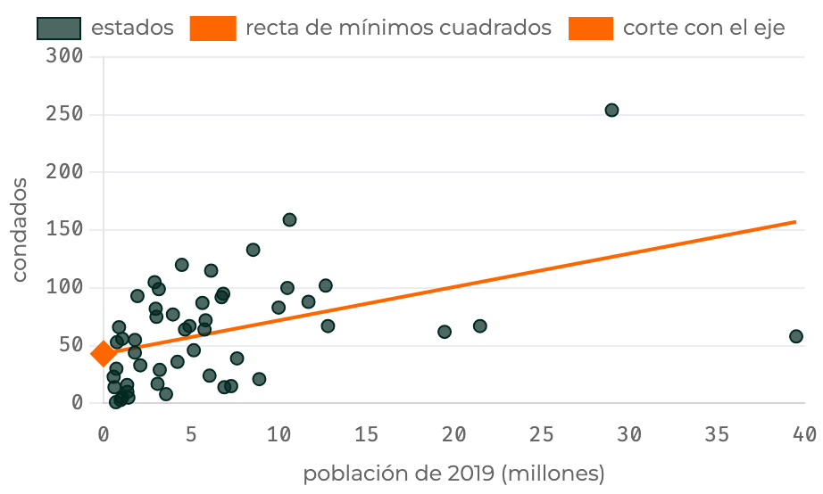

El simulador «La recta de Raj» del módulo 5 en su estado inicial: los 51 estados, counties frente a la población de 2019

- Dato \(\mathrm{cor}(x, y) = 0{,}46\), pero \(\mathrm{cor}(x, y^2/x) = -0{,}17\)
- Dato con 10 extracciones con reemplazo, el PPT tiene 963 006 y el MAS 557 287: un 73 % más
- `Lectura` no basta que \(y\) crezca con \(x\): 43 es el 70 % de la media, y los condados no crecen en proporción a la población

Fuente: cap. 6, módulo 5, bloque «El criterio de Raj sobre los estados» y simulador «La recta de Raj»; statepps.csv.

Capítulo 6 · Probabilidades desigualesMuestreo Estadístico · UnBosque32 / 38

El diseño πPT y cuándo gana

## Con counties, el sistemático pierde con la lista alfabética y gana con la ordenada

[figure not shown]

Varianza del HT de counties con n = 10 (exacta, salvo Brewer, con 4000 réplicas): el MAS sin reemplazo y, una a una, tres maneras de sortear el mismo πPT

- **deff:** la varianza del diseño entre la del MAS sin reemplazo (456 975); menor que 1, gana el diseño
- Dato sistemático: deff 1,26 con la lista alfabética y 0,75 con la ordenada; Brewer, que no depende del orden, unos 1,56
- `Lectura` recorrer la lista por tamaño estratifica de forma implícita; cambiar de algoritmo no arregla la falta de proporcionalidad

Fuente: cap. 6, módulo 5, bloque «El mismo piPT con distintos algoritmos», y la tabla de diseños del módulo 6.

Capítulo 6 · Probabilidades desigualesMuestreo Estadístico · UnBosque33 / 38

El diseño πPT y cuándo gana

## Con el agua de los estados, un solo estado basta para que el πPT pierda

| Variable de interés | Correlación con la población | deff del πPT sistemático |
| --- | --- | --- |
| `counties` | 0,46 | 1,26 |
| `waterarea` | 0,045 | 9 |

- Dato Alaska tiene poca población, así que \(\pi = 0{,}023\), y el 36 % del agua del país
- Dato con `waterarea`, el deff es 9 en cualquier orden de la lista
- `Lectura` \(y\) grande con \(\pi\) pequeña: el módulo 8, en la sesión 2, explica el mecanismo

Fuente: cap. 6, módulo 5 (simulador «¿Cuándo gana el πPT?» y «Un estado puede arruinarlo todo») y entrada del módulo 8; statepps.csv.

Capítulo 6 · Probabilidades desigualesMuestreo Estadístico · UnBosque34 / 38

Idea clave · lectura del material

## Correlación no es proporcionalidad

Lo que decide si el πPT gana es que \(y\) sea casi proporcional a \(x\). Ni la correlación ni cambiar de algoritmo lo arreglan; ordenar la lista ayuda, porque estratifica.

Capítulo 6 · Probabilidades desigualesMuestreo Estadístico · UnBosque35 / 38

Universidad El Bosque

Muestreo Estadístico

Capítulo 6 · Probabilidades desiguales

¿Por qué probabilidades desiguales?

El estimador de Hansen–Hurwitz

Cómo se sortea: acumulativo y Lahiri

Sin reemplazo: Horvitz–Thompson otra vez

El diseño πPT y cuándo gana

Cierre de la sesión 1

06

## Cierre de la sesión 1

Leer en el material: Autoevaluación y ejercicios guiados

36 / 38

Cierre de la sesión 1

## Lo que te llevas hoy

- Dividir entre la probabilidad de salir, conocida y positiva, deja **insesgado** el sorteo; la varianza la decide si \(y/\pi\) cambia poco
- Con reemplazo, **Hansen–Hurwitz** y \(\widehat{V} = s_z^2/n\); sin reemplazo, el **HT** del capítulo 2
- \(\psi\) es de una extracción y suma 1; \(\pi\) es de estar en la muestra y suma \(n\)
- Sin reemplazo no es automáticamente mejor: importa qué muestras deja salir el diseño
- **Correlación no basta:** Raj mira el signo de \(\mathrm{Cov}(x, y^2/x)\)

Javier Mauricio Sierra

Capítulo 6 · Probabilidades desigualesMuestreo Estadístico · UnBosque37 / 38

Cierre de la sesión 1

## Para la semana 13

1Autoevaluaciónrehaz sin mirar las siete primeras; la 5 y la 6 no se vieron en clase

→

2Ejercicio guiado 1Hansen–Hurwitz con statepps: ¿qué diseño «parece» mejor?

→

3Ejercicio guiado 2sortear 5 clases con el método acumulativo

→

4Lecturamódulos 6 y 7: Poisson y cómo estimar la varianza

Fuente: cap. 6, módulo 11 (autoevaluación y ejercicios guiados).

Capítulo 6 · Probabilidades desigualesMuestreo Estadístico · UnBosque38 / 38

### Atajos del teclado

[output not shown]

·

00:00

A continuación

Notas